# Examining the relationship between the big-5 personality facets and implicit racial attitudes

Data analysing

Tina Puskaric

11 Januar, 2024

# Dependencies

```r
library(tidyverse)
library(knitr)
library(kableExtra)
library(readr)
library(dplyr)
library(janitor)
library(scales)
library(patchwork)
library(ggplot2)
library(patchwork)
library(psych)
library(report)
```

#SET.SEED

```r
#I do it at the beginning and for reproducibility

set.seed(333)
```

# Data

- Exclude participants using the master exclusion variable.

```r
data_processed <- read_csv("../data/processed/data_processed.csv")


data_processed_after_exclusions <- data_processed |>
  filter(exclude_participant == "include")
```

# Sample descriptives

## Sample size before exclusions

- Create a table with the total number of participants before exclusions.

```r
data_processed |>
  count(name = "n") |>
  kable() |>
  add_header_above(header = c("Sample before exclusions" = 1)) |>
  kable_classic(full_width = FALSE)
```

| Sample before exclusions n |
| --- |
| 1479 |

## Sample size after exclusions

- Create a table with the total number of participants after exclusions.

```r
#much less now

data_processed_after_exclusions |>
  count(name = "n") |>
  kable() |>
  add_header_above(header = c("Sample after exclusions" = 1)) |>
  kable_classic(full_width = FALSE)
```

| Sample after exclusions n |
| --- |
| 161 |

## Demographics tables

- Create demographics tables that summarise the mean and SD age, and the frequency and percentage of men vs women in the sample. Report the proportion of participants for which each demographics variable was available.

### Age

```r
data_processed_after_exclusions |>
  rename(Age = age) |>
  mutate(Age = ifelse(Age %in% c("missing"), "Missing", "Available")) |>
  group_by(Age) %>%
  summarise(n = n()) %>%
  mutate(Percent = paste0(round_half_up((n / sum(n)) * 100, 1), "%")) |>
  kable() |>
  kable_classic(full_width = FALSE)
```

| Age | n | Percent |
| --- | --- | --- |
| Available | 139 | 86.3% |
| Missing | 22 | 13.7% |

```r
data_processed_after_exclusions |>
  filter(age != "missing")|>
  mutate(age = as.numeric(age)) |>
  summarise(Mean = mean(age, na.rm = TRUE),
            SD = sd(age, na.rm = TRUE))|>
  mutate_all(.funs = janitor::round_half_up, digits = 1) |>
  kable() |>
  add_header_above(header = c("Age" = 2)) |>
  kable_classic(full_width = FALSE)
```

| Age Mean | Age SD |
| --- | --- |
| 30.6 | 11.3 |

```r
#all persons including the missings - interestingly, there is no difference!

# data_processed_after_exclusions |>
#   mutate(age = as.numeric(age)) |>
#   summarise(Mean = mean(age, na.rm = TRUE),
#             SD = sd(age, na.rm = TRUE)) |>
#   mutate_all(.funs = janitor::round_half_up, digits = 1) |>
#   kable() |>
#   add_header_above(header = c("Age" = 2)) |>
#   kable_classic(full_width = FALSE)
#
```

### Gender

```r
data_processed_after_exclusions |>
  rename(Gender = gender) |>
  mutate(Gender = ifelse(Gender %in% c("missing"), "Missing", "Available")) |>
  group_by(Gender) %>%
  summarise(n = n()) %>%
  mutate(Percent = paste0(round_half_up((n / sum(n)) * 100, 1), "%")) |>
  mutate(Gender = stringr::str_to_sentence(Gender))|>
  kable() |>
  kable_classic(full_width = FALSE)
```

| Gender | n | Percent |
| --- | --- | --- |
| Available | 139 | 86.3% |
| Missing | 22 | 13.7% |

```r
data_processed_after_exclusions |>
  filter(gender != "missing")|>
  rename(Gender = gender) |>
  group_by(Gender) |>
  summarise(n = n()) |>
  mutate(Percent = paste0(round_half_up((n / sum(n)) * 100, 1), "%")) |>
  mutate(Gender = stringr::str_to_sentence(Gender)) |>
  kable() |>
  kable_classic(full_width = FALSE)
```

| Gender | n | Percent |
| --- | --- | --- |
| Female | 86 | 61.9% |
| Male | 53 | 38.1% |

```r
#including the missings - it makes a difference here!
#I left this code visible because 13,7% missing data


data_processed_after_exclusions |>
  rename(Gender = gender) |>
  group_by(Gender) |>
  summarise(n = n()) |>
  mutate(Percent = paste0(round_half_up((n / sum(n)) * 100, 1), "%")) |>
  mutate(Gender = stringr::str_to_sentence(Gender)) |>
  kable() |>
  kable_classic(full_width = FALSE)
```

| Gender | n | Percent |
| --- | --- | --- |
| Female | 86 | 53.4% |
| Male | 53 | 32.9% |
| Missing | 22 | 13.7% |

# Descriptives BFI & IAT

## Cronbach’s Alpha

- Calculate Cronbach’s alpha for each of the BFI subscales.

subset or select - it comes to the same thing, I decided on select because with subset the starts_with didn’t really wanted to work and I would rather work with starts_with because it is less error-prone than writing out the individual items.

I only output the one table where the raw alpha can be seen, otherwise there will be a lot of code in the HTML.

```r
#raw_alpha for Agreeableness: 0.78
alpha_agreeableness <- data_processed_after_exclusions |>
  select(starts_with("bfi_a")) |>
  na.omit() |>
  alpha()

print(alpha_agreeableness$total)
```

```
##  raw_alpha std.alpha   G6(smc) average_r      S/N        ase     mean        sd
##  0.7815914 0.7946555 0.8168341 0.3006919 3.869865 0.03556053 4.385013 0.7708746
##   median_r
##  0.3039661
```

```r
#raw_alpha for Openness: 0.81
alpha_openness <- data_processed_after_exclusions |>
  select(starts_with("bfi_o")) |>
  na.omit() |>
  alpha()

print(alpha_openness$total)
```

```
##  raw_alpha std.alpha   G6(smc) average_r      S/N        ase     mean        sd
##  0.8106527 0.8195953 0.8612932 0.3123884 4.543094 0.03054941 4.612791 0.7391245
##   median_r
##  0.3099905
```

```r
#raw_alpha for Extroversion: 0.82
alpha_extroversion <- data_processed_after_exclusions |>
  select(starts_with("bfi_e")) |>
  na.omit() |>
  alpha()

print(alpha_extroversion$total)
```

```
##  raw_alpha std.alpha   G6(smc) average_r      S/N        ase  mean        sd
##  0.8181232 0.8145321 0.8341984 0.3544101 4.391768 0.03110611 3.865 0.8654791
##   median_r
##  0.3677282
```

```r
#raw_alpha for Neuroticism: 0.78
alpha_neuroticism <- data_processed_after_exclusions |>
  select(starts_with("bfi_n")) |>
  na.omit() |>
  alpha()

print(alpha_neuroticism$total)
```

```
##  raw_alpha std.alpha   G6(smc) average_r      S/N        ase  mean        sd
##  0.7786548  0.780091 0.7926929 0.3071995 3.547335 0.03817666 3.075 0.8069588
##  median_r
##  0.330617
```

```r
#raw_alpha for Conscientiousness: 0.81
alpha_conscientiousness <- data_processed_after_exclusions |>
  select(starts_with("bfi_c")) |>
  na.omit() |>
  alpha()

print(alpha_conscientiousness$total)
```

```
##  raw_alpha std.alpha   G6(smc) average_r     S/N        ase     mean        sd
##  0.8107809 0.8194388 0.8385494 0.3352188 4.53829 0.03207928 4.358519 0.8007282
##   median_r
##  0.3221202
```

## Plots

- Create series of histograms of the distribution of scores on each of the BFI subscales and the IAT.

### IAT Plot

I chose the color green because *Green*wald’s D. ;D

I chose theme_minimal because the grid is in the background and I find it helpful. The X axis limit this way because the data ranged from -1 - 0.5 and so you can see cleary it’s asymmetric (+ Zero Line).

I made the D in D score in the axis crusive because it is an effect size.I will do the same for the other plots.

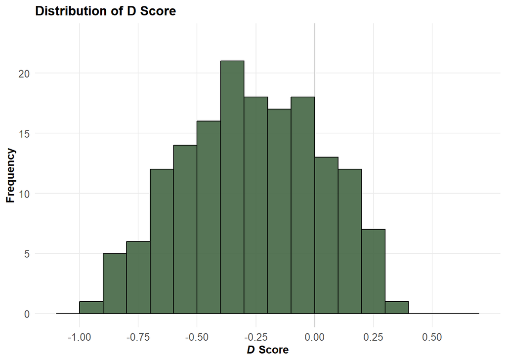

```r
ggplot(data_processed_after_exclusions, aes(x = D)) +
  geom_vline(xintercept = 0, linetype = "solid", color = "black", size = 0.1) +
  geom_histogram(binwidth = 0.1,
                 boundary = 1,
                 color = "#000000",
                 fill = "#446644",
                 alpha = 0.9) +
  labs(x = expression(paste(bolditalic("D"), bold(" Score"))),
       y = "Frequency",
       title = "Distribution of D Score") +
  scale_x_continuous(breaks = seq(-1, 0.7, by = 0.25), limits = c(-1.1, 0.7)) +
  scale_y_continuous(breaks = pretty_breaks(n = 4), limits = c(0, 23)) +
  theme_minimal() +
  theme(title = element_text(face = "bold"),
        axis.title = element_text(face = "bold"),
        axis.text = element_text(size = 10),
        panel.grid.minor = element_blank())
```

### BFI Plots

All plots have the same dimensions, if you want to compare them, it will be easier this way

I created new seperate datasets to avoid the warning that several rows have been removed, also I included D so that I can reuse this dataset for another task.

The colors were chosen so that they stand out enough (and because I like them).

If I had my way, *every single plot* would be in a yellow variation. :D

#### Agreeableness

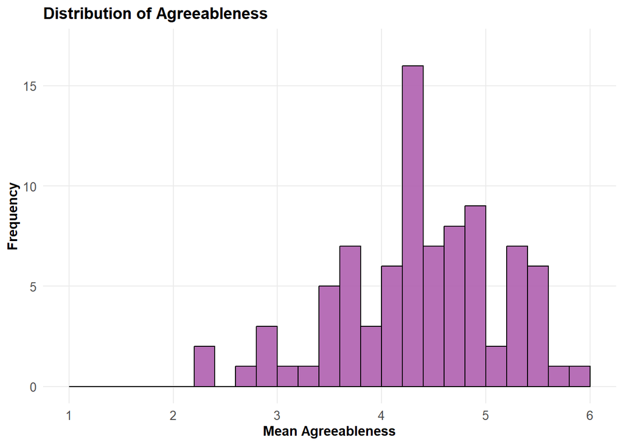

```r
mean_agree <- data_processed_after_exclusions|>
  select(mean_agreeableness, D)|>
  na.omit()


ggplot(mean_agree, aes(x = mean_agreeableness)) +
  geom_histogram(binwidth = 0.2,
                 boundary = 1,
                 color = "#000000",
                 fill = "#AF5FAF",
                 alpha = 0.9) +
  labs(x = "Mean Agreeableness",
       y = "Frequency",
       title = "Distribution of Agreeableness") +
  theme_minimal() +
  theme(title = element_text(face = "bold"),
        axis.title = element_text(face = "bold"),
        axis.text = element_text(size = 10),
        panel.grid.minor = element_blank()) +
  scale_x_continuous(breaks = pretty_breaks(n = 6), limits = c(1,6)) +
  scale_y_continuous(breaks = pretty_breaks(n = 6),  limits = c(0, 17))
```

#### Openness

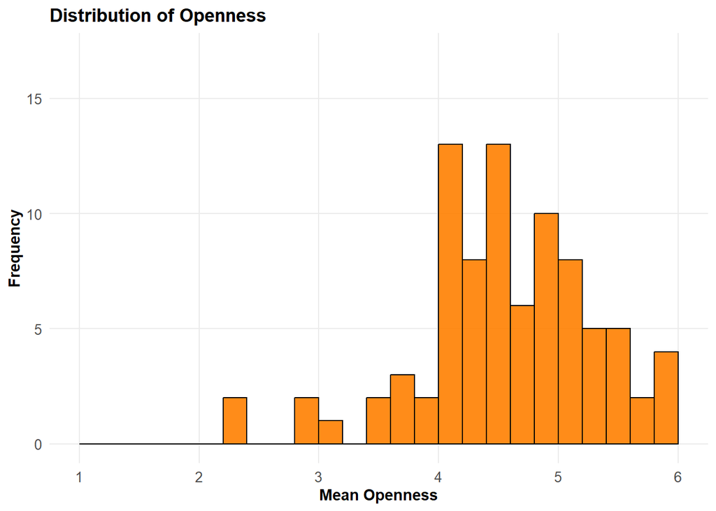

```r
mean_open <- data_processed_after_exclusions|>
  select(mean_openness, D)|>
  na.omit()

ggplot(mean_open, aes(x = mean_openness)) +
  geom_histogram(binwidth = 0.2,
                 boundary = 1,
                 color = "#000000",
                 fill = "#FF7F00",
                 alpha = 0.9) +
  labs(x = "Mean Openness",
       y = "Frequency",
       title = "Distribution of Openness") +
  theme_minimal() +
  theme(title = element_text(face = "bold"),
        axis.title = element_text(face = "bold"),
        axis.text = element_text(size = 10),
        panel.grid.minor = element_blank()) +
  scale_x_continuous(breaks = pretty_breaks(n = 6), limits = c(1,6)) +
  scale_y_continuous(breaks = pretty_breaks(n = 6),  limits = c(0, 17))
```

#### Extroversion

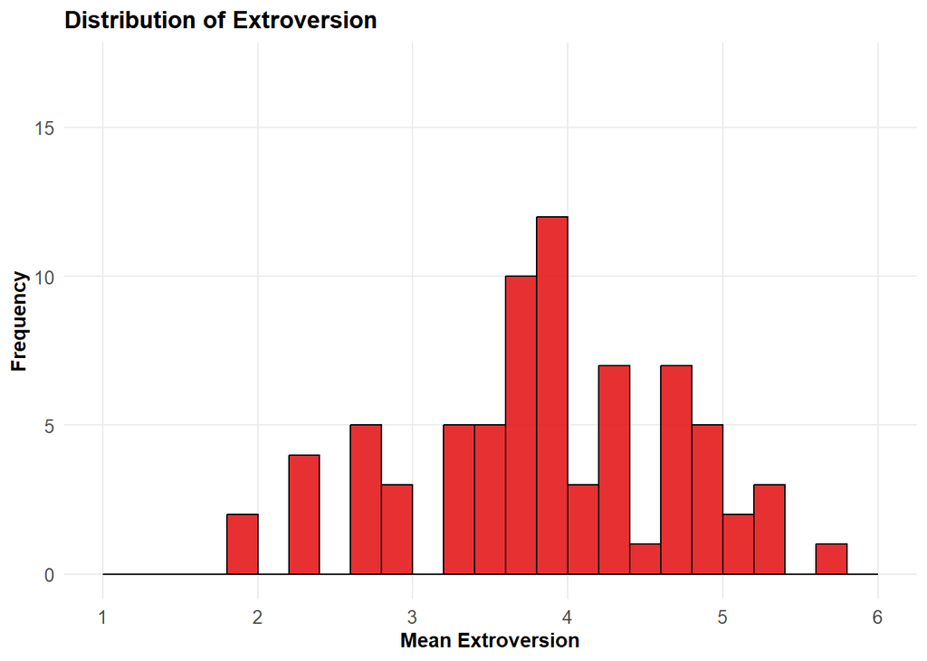

```r
mean_extro <- data_processed_after_exclusions|>
  select(mean_extroversion, D)|>
  na.omit()

ggplot(mean_extro, aes(x = mean_extroversion)) +
  geom_histogram(binwidth = 0.2,
                 boundary = 1,
                 color = "#000000",
                 fill = "#E41A1C",
                 alpha = 0.9) +
  labs(x = "Mean Extroversion",
       y = "Frequency",
       title = "Distribution of Extroversion") +
  theme_minimal() +
  theme(title = element_text(face = "bold"),
        axis.title = element_text(face = "bold"),
        axis.text = element_text(size = 10),
        panel.grid.minor = element_blank()) +
  scale_x_continuous(breaks = pretty_breaks(n = 6), limits = c(1,6)) +
  scale_y_continuous(breaks = pretty_breaks(n = 6),  limits = c(0, 17))
```

#### Neuroticism

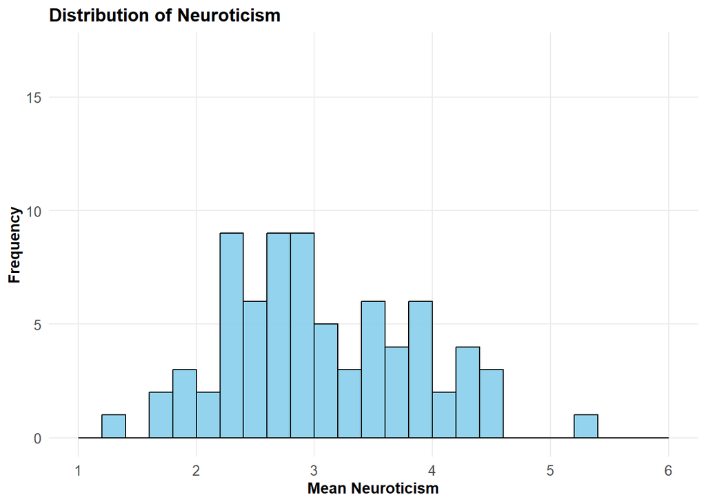

```r
mean_neuro <- data_processed_after_exclusions|>
  select(mean_neuroticism, D)|>
  na.omit()


ggplot(mean_neuro, aes(x = mean_neuroticism)) +
  geom_histogram(binwidth = 0.2,
                 boundary = 1,
                 color = "#000000",
                 fill = "#87CEEB",
                 alpha = 0.9) +
  labs(x = "Mean Neuroticism",
       y = "Frequency",
       title = "Distribution of Neuroticism") +
  theme_minimal() +
  theme(title = element_text(face = "bold"),
        axis.title = element_text(face = "bold"),
        axis.text = element_text(size = 10),
        panel.grid.minor = element_blank()) +
  scale_x_continuous(breaks = pretty_breaks(n = 6), limits = c(1,6)) +
  scale_y_continuous(breaks = pretty_breaks(n = 6),  limits = c(0, 17))
```

#### Conscientious

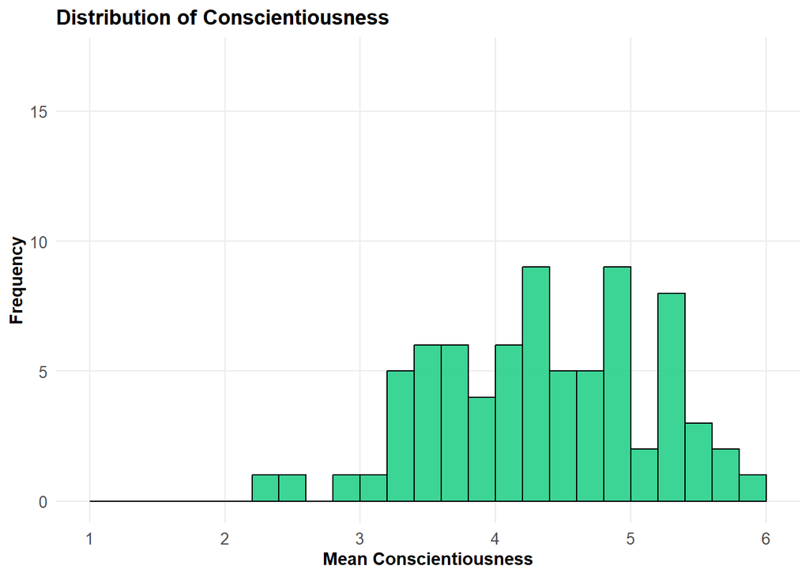

```r
mean_cons <- data_processed_after_exclusions|>
  select(mean_conscientiousness, D)|>
  na.omit()

ggplot(mean_cons, aes(x = mean_conscientiousness)) +
  geom_histogram(binwidth = 0.2,
                 boundary = 1,
                 color = "#000000",
                 fill = "#27d08b",
                 alpha = 0.9) +
  labs(x = "Mean Conscientiousness",
       y = "Frequency",
       title = "Distribution of Conscientiousness") +
  theme_minimal() +
  theme(title = element_text(face = "bold"),
        axis.title = element_text(face = "bold"),
        axis.text = element_text(size = 10),
        panel.grid.minor = element_blank()) +
  scale_x_continuous(breaks = pretty_breaks(n = 6), limits = c(1,6)) +
  scale_y_continuous(breaks = pretty_breaks(n = 6),  limits = c(0, 17))
```

## Correlation between IAT and BFI

- Create a table with a correlation matrix of the Pearson’s r correlations between the IAT and the BFI subscales rounded to two decimal places.

```r
# meanscores_correlations
data_processed_after_exclusions |>
  select(D, starts_with(c("mean_"))) |>
  cor(method = "pearson", use = "pairwise.complete.obs")|> #only takes values for the correlation if they exist in pairs
  round(2)|>
  kable() |>
  kable_classic(full_width = FALSE)|>
  add_header_above(header = c("Correlation between BFI Scales and IAT" = 7),  align = "left")
```

| Correlation between BFI Scales and IAT | Correlation between BFI Scales and IAT D | Correlation between BFI Scales and IAT mean_agreeableness | Correlation between BFI Scales and IAT mean_openness | Correlation between BFI Scales and IAT mean_extroversion | Correlation between BFI Scales and IAT mean_neuroticism | Correlation between BFI Scales and IAT mean_conscientiousness |
| --- | --- | --- | --- | --- | --- | --- |
| D | 1.00 | -0.05 | -0.01 | 0.10 | 0.07 | -0.07 |
| mean_agreeableness | -0.05 | 1.00 | 0.14 | NA | NA | NA |
| mean_openness | -0.01 | 0.14 | 1.00 | NA | NA | NA |
| mean_extroversion | 0.10 | NA | NA | 1.00 | -0.10 | 0.09 |
| mean_neuroticism | 0.07 | NA | NA | -0.10 | 1.00 | -0.33 |
| mean_conscientiousness | -0.07 | NA | NA | 0.09 | -0.33 | 1.00 |

```r
# items_correlations - I also wanted to do it out of interest

# data_processed_after_exclusions |>
#   select(D, starts_with(c("bfi_"))) |>
#   cor(use = "pairwise.complete.obs")|>
#   round(2)|>
#   kable() |>
#   kable_classic(full_width = FALSE)|>
#   add_header_above(header = c("Correlation between BFI Items and IAT" = 46),  align = "c")
```

# Analyses & hypothesis tests

## T Test

- Run a t-test to test the hypothesis that men and women differ on their scores on the IAT. Report and interpret the results using {report}.

*Conclusion*: Since there is no significance, it can be assumed that gender does not influence the IAT score.

I added also the report_table, because i think its also helpful.

I was unsure which scores I should use and also made the T-tests for mean1 and mean2, but stored them in markdowns.

```r
#preparing the dataset for the t tests
data_t_test<- data_processed_after_exclusions|>
    filter(gender %in% c("female", "male"))

t_test_D <- t.test(D ~ gender, data = data_t_test)
report_table(t_test_D)
```

```
## Welch Two Sample t-test
##
## Parameter |  Group | Mean_Group1 | Mean_Group2 | Difference |        95% CI | t(111.55) |     p |    d |         d  CI
## ----------------------------------------------------------------------------------------------------------------------
## D         | gender |       -0.25 |       -0.28 |       0.04 | [-0.06, 0.14] |      0.77 | 0.442 | 0.15 | [-0.23, 0.52]
##
## Alternative hypothesis: two.sided
```

```r
report(t_test_D)
```

```
## Effect sizes were labelled following Cohen's (1988) recommendations.
##
## The Welch Two Sample t-test testing the difference of D by gender (mean in
## group female = -0.25, mean in group male = -0.28) suggests that the effect is
## positive, statistically not significant, and very small (difference = 0.04, 95%
## CI [-0.06, 0.14], t(111.55) = 0.77, p = 0.442; Cohen's d = 0.15, 95% CI [-0.23,
## 0.52])
```

```r
#report and report_text do the same thing in our case here


# t_test_mean1 <- t.test(mean1 ~ gender, data = data_t_test)
# report_table(t_test_mean1)
# report_text(t_test_mean1)
#
# t_test_mean2 <- t.test(mean2 ~ gender, data = data_t_test)
# report_table(t_test_mean2)
# report_text(t_test_mean2)
```

## Regressions

- Run a series of regressions to test the hypotheses that each BFI subscale predicts IAT scores. Run separate regressions for each subscale rather than a multiple regression. Report and interpret the results using {report}.

I have given all facets their own heading to make it clearer.

I also used the summary function because I found it helpful.

The Mean1 and Mean2 regressions are in the markdowns.

### Agreeableness

```r
# for Agreeableness
regression_agreeableness_D <- lm(D ~ mean_agreeableness, data = data_processed_after_exclusions)
report(regression_agreeableness_D)
```

```
## We fitted a linear model (estimated using OLS) to predict D with
## mean_agreeableness (formula: D ~ mean_agreeableness). The model explains a
## statistically not significant and very weak proportion of variance (R2 =
## 2.63e-03, F(1, 84) = 0.22, p = 0.639, adj. R2 = -9.25e-03). The model's
## intercept, corresponding to mean_agreeableness = 0, is at -0.18 (95% CI [-0.55,
## 0.19], t(84) = -0.96, p = 0.340). Within this model:
##
##   - The effect of mean agreeableness is statistically non-significant and
## negative (beta = -0.02, 95% CI [-0.10, 0.06], t(84) = -0.47, p = 0.639; Std.
## beta = -0.05, 95% CI [-0.27, 0.17])
##
## Standardized parameters were obtained by fitting the model on a standardized
## version of the dataset. 95% Confidence Intervals (CIs) and p-values were
## computed using a Wald t-distribution approximation.
```

```r
summary(regression_agreeableness_D)
```

```
##
## Call:
## lm(formula = D ~ mean_agreeableness, data = data_processed_after_exclusions)
##
## Residuals:
##      Min       1Q   Median       3Q      Max
## -0.62978 -0.21924 -0.01155  0.21828  0.59215
##
## Coefficients:
##                    Estimate Std. Error t value Pr(>|t|)
## (Intercept)         -0.1796     0.1874  -0.959    0.340
## mean_agreeableness  -0.0198     0.0421  -0.470    0.639
##
## Residual standard error: 0.2992 on 84 degrees of freedom
##   (75 Beobachtungen als fehlend gelöscht)
## Multiple R-squared:  0.002625,   Adjusted R-squared:  -0.009248
## F-statistic: 0.2211 on 1 and 84 DF,  p-value: 0.6394
```

```r
# regression_agreeableness_mean1 <- lm(mean1 ~ mean_agreeableness, data = data_processed_after_exclusions)
# regression_agreeableness_mean2 <- lm(mean2 ~ mean_agreeableness, data = data_processed_after_exclusions)
#
#
# report(regression_agreeableness_mean1)
# summary(regression_agreeableness_mean1)
#
# report(regression_agreeableness_mean2)
# summary(regression_agreeableness_mean2)
```

### Openness

```r
# for Openness
regression_openness_D <- lm(D ~ mean_openness, data = data_processed_after_exclusions)
report(regression_openness_D)
```

```
## We fitted a linear model (estimated using OLS) to predict D with mean_openness
## (formula: D ~ mean_openness). The model explains a statistically not
## significant and very weak proportion of variance (R2 = 1.16e-04, F(1, 84) =
## 9.77e-03, p = 0.921, adj. R2 = -0.01). The model's intercept, corresponding to
## mean_openness = 0, is at -0.25 (95% CI [-0.65, 0.16], t(84) = -1.20, p =
## 0.234). Within this model:
##
##   - The effect of mean openness is statistically non-significant and negative
## (beta = -4.35e-03, 95% CI [-0.09, 0.08], t(84) = -0.10, p = 0.921; Std. beta =
## -0.01, 95% CI [-0.23, 0.21])
##
## Standardized parameters were obtained by fitting the model on a standardized
## version of the dataset. 95% Confidence Intervals (CIs) and p-values were
## computed using a Wald t-distribution approximation.
```

```r
summary(regression_openness_D)
```

```
##
## Call:
## lm(formula = D ~ mean_openness, data = data_processed_after_exclusions)
##
## Residuals:
##      Min       1Q   Median       3Q      Max
## -0.62618 -0.21453 -0.01605  0.22749  0.60411
##
## Coefficients:
##                Estimate Std. Error t value Pr(>|t|)
## (Intercept)   -0.246401   0.205333  -1.200    0.234
## mean_openness -0.004345   0.043960  -0.099    0.921
##
## Residual standard error: 0.2996 on 84 degrees of freedom
##   (75 Beobachtungen als fehlend gelöscht)
## Multiple R-squared:  0.0001163,  Adjusted R-squared:  -0.01179
## F-statistic: 0.009772 on 1 and 84 DF,  p-value: 0.9215
```

```r
# regression_openness_mean1 <- lm(mean1 ~ mean_openness, data = data_processed_after_exclusions)
# regression_openness_mean2 <- lm(mean2 ~ mean_openness, data = data_processed_after_exclusions)
#
# report(regression_openness_mean1)
# summary(regression_openness_mean1)
#
# report(regression_openness_mean2)
# summary(regression_openness_mean2)
```

### Extroversion

```r
# for Extroversion
regression_extroversion_D <- lm(D ~ mean_extroversion, data = data_processed_after_exclusions)
report(regression_extroversion_D)
```

```
## We fitted a linear model (estimated using OLS) to predict D with
## mean_extroversion (formula: D ~ mean_extroversion). The model explains a
## statistically not significant and very weak proportion of variance (R2 = 0.01,
## F(1, 73) = 0.77, p = 0.383, adj. R2 = -3.11e-03). The model's intercept,
## corresponding to mean_extroversion = 0, is at -0.41 (95% CI [-0.71, -0.11],
## t(73) = -2.71, p = 0.008). Within this model:
##
##   - The effect of mean extroversion is statistically non-significant and positive
## (beta = 0.03, 95% CI [-0.04, 0.11], t(73) = 0.88, p = 0.383; Std. beta = 0.10,
## 95% CI [-0.13, 0.33])
##
## Standardized parameters were obtained by fitting the model on a standardized
## version of the dataset. 95% Confidence Intervals (CIs) and p-values were
## computed using a Wald t-distribution approximation.
```

```r
summary(regression_extroversion_D)
```

```
##
## Call:
## lm(formula = D ~ mean_extroversion, data = data_processed_after_exclusions)
##
## Residuals:
##      Min       1Q   Median       3Q      Max
## -0.69260 -0.23323  0.00963  0.20017  0.53671
##
## Coefficients:
##                   Estimate Std. Error t value Pr(>|t|)
## (Intercept)       -0.41147    0.15158  -2.714  0.00828 **
## mean_extroversion  0.03361    0.03828   0.878  0.38292
## ---
## Signif. codes:  0 '***' 0.001 '**' 0.01 '*' 0.05 '.' 0.1 ' ' 1
##
## Residual standard error: 0.285 on 73 degrees of freedom
##   (86 Beobachtungen als fehlend gelöscht)
## Multiple R-squared:  0.01045,    Adjusted R-squared:  -0.00311
## F-statistic: 0.7706 on 1 and 73 DF,  p-value: 0.3829
```

```r
# regression_extroversion_mean1 <- lm(mean1 ~ mean_extroversion, data = data_processed_after_exclusions)
# regression_extroversion_mean2 <- lm(mean2 ~ mean_extroversion, data = data_processed_after_exclusions)
#
# report(regression_extroversion_mean1)
# summary(regression_extroversion_mean1)
#
# report(regression_extroversion_mean2)
# summary(regression_extroversion_mean2)
```

### Neuroticism

```r
# for Neuroticism

regression_neuroticism_D <- lm(D ~ mean_neuroticism, data = data_processed_after_exclusions)
report(regression_neuroticism_D)
```

```
## We fitted a linear model (estimated using OLS) to predict D with
## mean_neuroticism (formula: D ~ mean_neuroticism). The model explains a
## statistically not significant and very weak proportion of variance (R2 =
## 5.08e-03, F(1, 73) = 0.37, p = 0.544, adj. R2 = -8.55e-03). The model's
## intercept, corresponding to mean_neuroticism = 0, is at -0.36 (95% CI [-0.62,
## -0.10], t(73) = -2.74, p = 0.008). Within this model:
##
##   - The effect of mean neuroticism is statistically non-significant and positive
## (beta = 0.03, 95% CI [-0.06, 0.11], t(73) = 0.61, p = 0.544; Std. beta = 0.07,
## 95% CI [-0.16, 0.30])
##
## Standardized parameters were obtained by fitting the model on a standardized
## version of the dataset. 95% Confidence Intervals (CIs) and p-values were
## computed using a Wald t-distribution approximation.
```

```r
summary(regression_neuroticism_D)
```

```
##
## Call:
## lm(formula = D ~ mean_neuroticism, data = data_processed_after_exclusions)
##
## Residuals:
##     Min      1Q  Median      3Q     Max
## -0.6872 -0.1983  0.0185  0.2105  0.4942
##
## Coefficients:
##                  Estimate Std. Error t value Pr(>|t|)
## (Intercept)      -0.35885    0.13083  -2.743  0.00766 **
## mean_neuroticism  0.02513    0.04117   0.610  0.54355
## ---
## Signif. codes:  0 '***' 0.001 '**' 0.01 '*' 0.05 '.' 0.1 ' ' 1
##
## Residual standard error: 0.2858 on 73 degrees of freedom
##   (86 Beobachtungen als fehlend gelöscht)
## Multiple R-squared:  0.005077,   Adjusted R-squared:  -0.008553
## F-statistic: 0.3725 on 1 and 73 DF,  p-value: 0.5436
```

```r
# regression_neuroticism_mean1 <- lm(mean1 ~ mean_neuroticism, data = data_processed_after_exclusions)
# regression_neuroticism_mean2 <- lm(mean2 ~ mean_neuroticism, data = data_processed_after_exclusions)
#
# report(regression_neuroticism_mean1)
# summary(regression_neuroticism_mean1)
#
# report(regression_neuroticism_mean2)
# summary(regression_neuroticism_mean2)
```

### Conscientiousness

```r
# for Conscientiousness

regression_conscientiousness_D <- lm(D ~ mean_conscientiousness, data = data_processed_after_exclusions)
report(regression_conscientiousness_D)
```

```
## We fitted a linear model (estimated using OLS) to predict D with
## mean_conscientiousness (formula: D ~ mean_conscientiousness). The model
## explains a statistically not significant and very weak proportion of variance
## (R2 = 4.53e-03, F(1, 73) = 0.33, p = 0.566, adj. R2 = -9.11e-03). The model's
## intercept, corresponding to mean_conscientiousness = 0, is at -0.18 (95% CI
## [-0.54, 0.19], t(73) = -0.96, p = 0.338). Within this model:
##
##   - The effect of mean conscientiousness is statistically non-significant and
## negative (beta = -0.02, 95% CI [-0.11, 0.06], t(73) = -0.58, p = 0.566; Std.
## beta = -0.07, 95% CI [-0.30, 0.17])
##
## Standardized parameters were obtained by fitting the model on a standardized
## version of the dataset. 95% Confidence Intervals (CIs) and p-values were
## computed using a Wald t-distribution approximation.
```

```r
summary(regression_conscientiousness_D)
```

```
##
## Call:
## lm(formula = D ~ mean_conscientiousness, data = data_processed_after_exclusions)
##
## Residuals:
##      Min       1Q   Median       3Q      Max
## -0.68095 -0.20746  0.01326  0.20478  0.51965
##
## Coefficients:
##                        Estimate Std. Error t value Pr(>|t|)
## (Intercept)            -0.17737    0.18388  -0.965    0.338
## mean_conscientiousness -0.02391    0.04150  -0.576    0.566
##
## Residual standard error: 0.2859 on 73 degrees of freedom
##   (86 Beobachtungen als fehlend gelöscht)
## Multiple R-squared:  0.004526,   Adjusted R-squared:  -0.009111
## F-statistic: 0.3319 on 1 and 73 DF,  p-value: 0.5663
```

```r
# regression_conscientiousness_mean1 <- lm(mean1 ~ mean_conscientiousness, data = data_processed_after_exclusions)
# regression_conscientiousness_mean2 <- lm(mean2 ~ mean_conscientiousness, data = data_processed_after_exclusions)
#
# report(regression_conscientiousness_mean1)
# summary(regression_conscientiousness_mean1)
#
# report(regression_conscientiousness_mean2)
# summary(regression_conscientiousness_mean2)
```

# BFI Scatter Plots

- Create series of scatter plots of how BFI subscale scores predict IAT scores. Add regression lines. These plots therefore illustrate the same results as the regressions above. Make the plots presentable and publication quality- you may decide the details of this with one exception: Extreme scores on the IAT (defined as participants whose scores in the top and bottom 10% of IAT scores) should use a triangular shape rather than a dot.

## Single Plots

I use the data set from the previous task where we had to create plots so that I don’t get an unnecessary error warning. Also I created a new Variable for the top and bottom D Scores.

I chose the Theme_Classic because in most publications the background is blank and everything is kept very minimalistic.

I used light vs dark color so that colorblind people can see the contrast, along with the shape.

In publications it’s not common to bold titles (at least APA says that) like that, but you said we have freedom as long as it’s presentable and I think bold titles make it presentable. :)

The limits are set a little wider so that the points can be displayed well and are not possibly cut off.

For the X axis, I chose values from 1 to 6 because these are the boundaries and we represented the data from 1 to 6. I chose the values -1 to 0.5 for the Y axis because a larger bandwidth would result in too much white space and it would not be necessary because all data can be successfully mapped in this way. In addition, I added a zero line for the Y axis to emphasize the asymmetric distribution of the data.

I didn’t label all the ticks on the Y axis because I wanted to find a balance between the HTML output and PNGs. If I had left all the ticks labeled, it wouldn’t have looked as nice in the document and HTML. As it is, the unlabeled ticks are still helpful and serve their purpose.

I have used the same dimensions for all scatterplots so that they remain comparable in the combined plot.

### Agreeableness

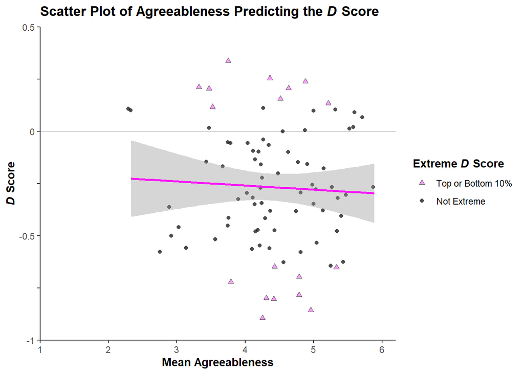

```r
# for Agreeableness


mean_agree$extreme <- ifelse(mean_agree$D >= quantile(mean_agree$D, 0.9) |
                               mean_agree$D <= quantile(mean_agree$D, 0.1),
                     "extreme", "not extreme")

plot_agree <- ggplot(mean_agree, aes(x = mean_agreeableness, y = D)) +
  geom_hline(yintercept = 0, linetype = "solid", color = "darkgrey", size = 0.05) +
  geom_point(size = 1.5, alpha = 0.7, aes(fill = extreme, shape = extreme), position = "jitter") +
  scale_shape_manual(values = c("not extreme" = 16, "extreme" = 24),
                     name = expression(paste(bold("Extreme "),bolditalic("D"), bold(" Score"))),
                     labels = c("Top or Bottom 10%", "Not Extreme")) +
  scale_fill_manual(values = c("not extreme" = "#000000", "extreme" = "#fb75fb"),
                    name = expression(paste(bold("Extreme "),bolditalic("D"), bold(" Score"))),
                    labels = c("Top or Bottom 10%", "Not Extreme")) +
  geom_smooth(method = "lm", color = "#f915f9", se = TRUE) +
  labs(x = "Mean Agreeableness",
       y = expression(paste(bolditalic("D"), bold(" Score"))),
       title = expression(paste(bold("Scatter Plot of Agreeableness Predicting the "),
                                           bolditalic("D"), bold(" Score")))) +
  scale_x_continuous(breaks = pretty_breaks(n = 6), limits = c(1, 6.2)) +
  scale_y_continuous(breaks = c(-1, -0.75, -0.5, -0.25, 0, 0.25, 0.5),  limits = c(-1, 0.5),
                     labels = c(-1, "", -0.5, "", 0, "", 0.5)) +
  expand_limits(x = c(1, 6), y = c(-1, 1)) +
  coord_cartesian(expand = FALSE) +
  theme_classic()+
  theme(title = element_text(face = "bold"),
        axis.title = element_text(face = "bold"))

print(plot_agree)
```

### Openness

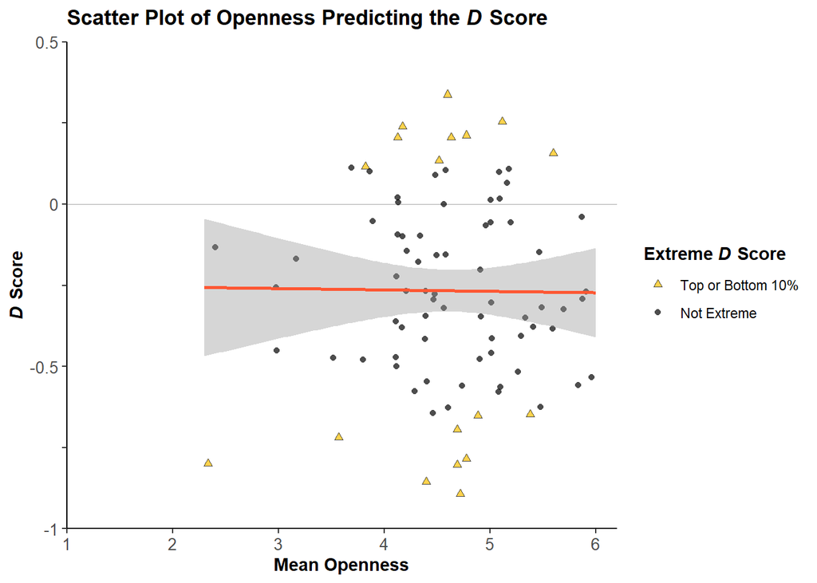

```r
# for Openness

mean_open$extreme <- ifelse(mean_open$D >= quantile(mean_open$D, 0.9) |
                               mean_open$D <= quantile(mean_open$D, 0.1),
                     "extreme", "not extreme")

plot_open <- ggplot(mean_open, aes(x = mean_openness, y = D)) +
  geom_hline(yintercept = 0, linetype = "solid", color = "darkgrey", size = 0.05) +
  geom_point(size = 1.5, alpha = 0.7, aes(fill = extreme, shape = extreme), position = "jitter") +
  scale_shape_manual(values = c("not extreme" = 16, "extreme" = 24),
                     name = expression(paste(bold("Extreme "),bolditalic("D"), bold(" Score"))),
                     labels = c("Top or Bottom 10%", "Not Extreme")) +
  scale_fill_manual(values = c("not extreme" = "#000000", "extreme" = "#FFBF00"),
                    name = expression(paste(bold("Extreme "),bolditalic("D"), bold(" Score"))),
                    labels = c("Top or Bottom 10%", "Not Extreme")) +
  geom_smooth(method = "lm", color = "#FF5733", se = TRUE) +
  labs(x = "Mean Openness",
       y = expression(paste(bolditalic("D"), bold(" Score"))),
       title = expression(paste(bold("Scatter Plot of Openness Predicting the "),
                                           bolditalic("D"), bold(" Score")))) +
  scale_x_continuous(breaks = pretty_breaks(n = 6), limits = c(1, 6.2)) +
  scale_y_continuous(breaks = c(-1, -0.75, -0.5, -0.25, 0, 0.25, 0.5),  limits = c(-1, 0.5),
                     labels = c(-1, "", -0.5, "", 0, "", 0.5)) +
  expand_limits(x = c(1, 6), y = c(-1, 1)) +
  coord_cartesian(expand = FALSE) +
  theme_classic() +
  theme(title = element_text(face = "bold"),
        axis.title = element_text(face = "bold"),
        axis.text = element_text(size = 10))

print(plot_open)
```

### Extroversion

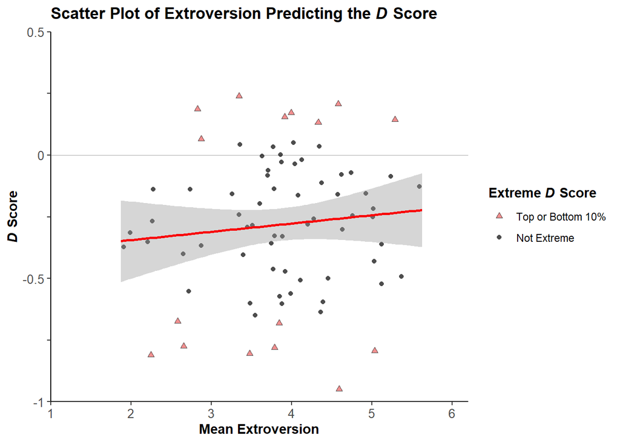

```r
# for Extroversion

mean_extro$extreme <- ifelse(mean_extro$D >= quantile(mean_extro$D, 0.9) |
                               mean_extro$D <= quantile(mean_extro$D, 0.1),
                     "extreme", "not extreme")

plot_extro <- ggplot(mean_extro, aes(x = mean_extroversion, y = D)) +
  geom_hline(yintercept = 0, linetype = "solid", color = "darkgrey", size = 0.05) +
  geom_point(size = 1.5, alpha = 0.7, aes(fill = extreme, shape = extreme), position = "jitter") +
  scale_shape_manual(values = c("not extreme" = 16, "extreme" = 24),
                     name = expression(paste(bold("Extreme "),bolditalic("D"), bold(" Score"))),
                     labels = c("Top or Bottom 10%", "Not Extreme")) +
  scale_fill_manual(values = c("not extreme" = "#000000", "extreme" = "#ed5e5f"),
                    name = expression(paste(bold("Extreme "),bolditalic("D"), bold(" Score"))),
                    labels = c("Top or Bottom 10%", "Not Extreme")) +
  geom_smooth(method = "lm", color = "#f80609", se = TRUE) +
  labs(x = "Mean Extroversion",
       y = expression(paste(bolditalic("D"), bold(" Score"))),
       title = expression(paste(bold("Scatter Plot of Extroversion Predicting the "),
                                           bolditalic("D"), bold(" Score")))) +
  scale_x_continuous(breaks = pretty_breaks(n = 6), limits = c(1, 6.2)) +
  scale_y_continuous(breaks = c(-1, -0.75, -0.5, -0.25, 0, 0.25, 0.5),  limits = c(-1, 0.5),
                     labels = c(-1, "", -0.5, "", 0, "", 0.5)) +
  expand_limits(x = c(1, 6), y = c(-1, 1)) +
  coord_cartesian(expand = FALSE) +
  theme_classic() +
  theme(title = element_text(face = "bold"),
        axis.title = element_text(face = "bold"),
        axis.text = element_text(size = 10))

print(plot_extro)
```

### Neuroticism

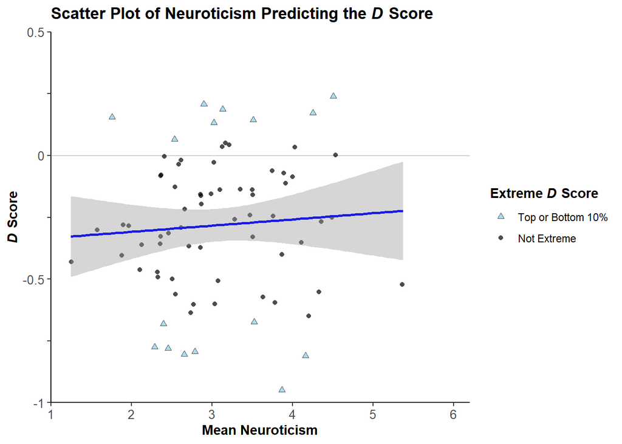

```r
# for Neuroticism

mean_neuro$extreme <- ifelse(mean_neuro$D >= quantile(mean_neuro$D, 0.9) |
                               mean_neuro$D <= quantile(mean_neuro$D, 0.1),
                     "extreme", "not extreme")

plot_neuro <- ggplot(mean_neuro, aes(x = mean_neuroticism, y = D)) +
  geom_hline(yintercept = 0, linetype = "solid", color = "darkgrey", size = 0.05) +
  geom_point(size = 1.5, alpha = 0.7, aes(fill = extreme, shape = extreme), position = "jitter") +
  scale_shape_manual(values = c("not extreme" = 16, "extreme" = 24),
                     name = expression(paste(bold("Extreme "),bolditalic("D"), bold(" Score"))),
                     labels = c("Top or Bottom 10%", "Not Extreme")) +
  scale_fill_manual(values = c("not extreme" = "#000000", "extreme" = "#87CEEB"),
                    name = expression(paste(bold("Extreme "),bolditalic("D"), bold(" Score"))),
                    labels = c("Top or Bottom 10%", "Not Extreme")) +
  geom_smooth(method = "lm", color = "#1a1ce4", se = TRUE) +
  labs(x = "Mean Neuroticism",
       y = expression(paste(bolditalic("D"), bold(" Score"))),
       title = expression(paste(bold("Scatter Plot of Neuroticism Predicting the "),
                                           bolditalic("D"), bold(" Score")))) +
  scale_x_continuous(breaks = pretty_breaks(n = 6), limits = c(1, 6.2)) +
  scale_y_continuous(breaks = c(-1, -0.75, -0.5, -0.25, 0, 0.25, 0.5),  limits = c(-1, 0.5),
                     labels = c(-1, "", -0.5, "", 0, "", 0.5)) +
  expand_limits(x = c(1, 6), y = c(-1, 1)) +
  coord_cartesian(expand = FALSE) +
  theme_classic() +
  theme(title = element_text(face = "bold"),
        axis.title = element_text(face = "bold"),
        axis.text = element_text(size = 10))

print(plot_neuro)
```

### Conscientiousness

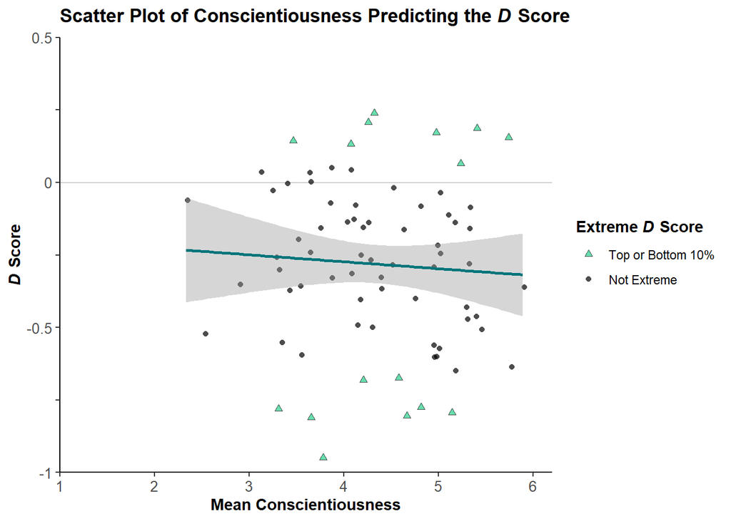

```r
# for Conscientiousness

mean_cons$extreme <- ifelse(mean_cons$D >= quantile(mean_cons$D, 0.9) |
                               mean_cons$D <= quantile(mean_cons$D, 0.1),
                     "extreme", "not extreme")

plot_cons <- ggplot(mean_cons, aes(x = mean_conscientiousness, y = D)) +
  geom_hline(yintercept = 0, linetype = "solid", color = "darkgrey", size = 0.05)+
  geom_point(size = 1.5, alpha = 0.7, aes(fill = extreme, shape = extreme), position = "jitter") +
  scale_shape_manual(values = c("not extreme" = 16, "extreme" = 24),
                     name = expression(paste(bold("Extreme "),bolditalic("D"), bold(" Score"))),
                     labels = c("Top or Bottom 10%", "Not Extreme")) +
  scale_fill_manual(values = c("not extreme" = "#000000", "extreme" = "#27d08b"),
                    name = expression(paste(bold("Extreme "),bolditalic("D"), bold(" Score"))),
                    labels = c("Top or Bottom 10%", "Not Extreme")) +
  geom_smooth(method = "lm", color = "#00757b", se = TRUE) +
  labs(x = "Mean Conscientiousness",
       y = expression(paste(bolditalic("D"), bold(" Score"))),
       title = expression(paste(bold("Scatter Plot of Conscientiousness Predicting the "),
                                           bolditalic("D"), bold(" Score")))) +
  scale_x_continuous(breaks = pretty_breaks(n = 6), limits = c(1, 6.2)) +
  scale_y_continuous(breaks = c(-1, -0.75, -0.5, -0.25, 0, 0.25, 0.5),  limits = c(-1, 0.5),
                     labels = c(-1, "", -0.5, "", 0, "", 0.5)) +
  expand_limits(x = c(1, 6), y = c(-1, 1)) +
  coord_cartesian(expand = FALSE) +
  theme_classic() +
  theme(title = element_text(face = "bold"),
        axis.title = element_text(face = "bold"),
        axis.text = element_text(size = 10))

print(plot_cons)
```

## BFI Plots combining

- A single combined plot should be created, containing 5 component plots, with the personality facet being examined in each clearly labelled. This plot should be printed in the html file but also saved to disk as both png/pdf.
- Combine these scatter plots into one ggplot object using {patchwork} and print the combined plot in your .Rmd and .html.

I think this is the same task?

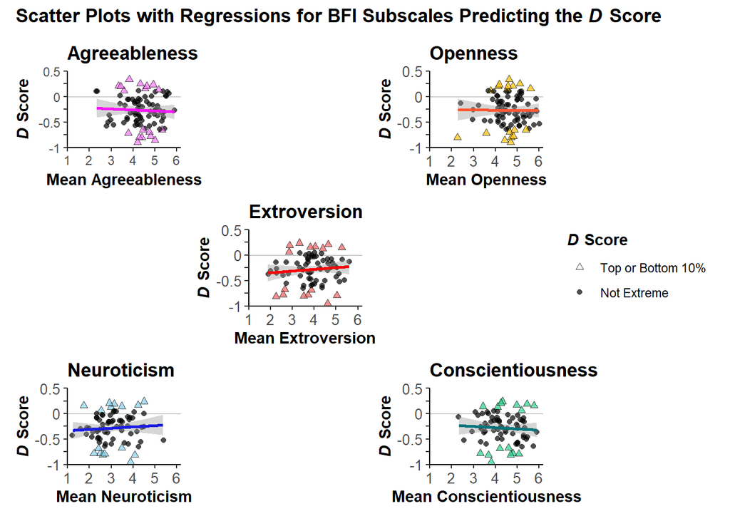

```r
#I chose this layout because I like it
#and wanted to experiment with it
layout <- "
A#B
#C#
D#E
"

#seperate guide, so that the same guide does not appear five times in different colors
plot_guide <- ggplot(mean_cons, aes(x = mean_conscientiousness, y = D)) +
  geom_point(size = 1.5, alpha = 0.7, aes(shape = extreme)) +
  scale_shape_manual(values = c("not extreme" = 16, "extreme" = 24),
                     name = expression(paste(bolditalic("D"), bold(" Score"))),
                     labels = c("Top or Bottom 10%", "Not Extreme"))

#Place Z in the layout does not exist,
#so the plot that I only created because of the guide will be dropped
#-> the legend is kept
plot_temp <- wrap_plots(A = plot_agree + labs(title = "Agreeableness") + theme(legend.position = "none"),
                   B = plot_open + labs(title = "Openness") + theme(legend.position = "none"),
                   C = plot_extro + labs(title = "Extroversion") + theme(legend.position = "none"),
                   D = plot_neuro + labs(title = "Neuroticism") + theme(legend.position = "none"),
                   E = plot_cons + labs(title = "Conscientiousness") + theme(legend.position = "none"),
                   Z = plot_guide,
                   design = layout) +
  theme_classic()


plot_comb_bfi <- plot_temp +
  plot_layout(guides = 'collect', design = layout) &
  theme(axis.title = element_text(face = "plain"),
        legend.title = element_text(face = "bold"))  &
  plot_annotation(title =  "Scatter Plots with Regressions for BFI Subscales Predicting the D Score",
                  theme = theme(plot.title = element_text(face = "bold")))

plot_comb_bfi <- plot_temp +
  plot_layout(guides = 'collect', design = layout) +
  theme(axis.title = element_text(face = "plain"),
        legend.title = element_text(face = "bold"),
        plot.title = element_text(face = "bold")) +
  plot_annotation(title = expression(paste(bold("Scatter Plots with Regressions for BFI Subscales Predicting the "),
                                           bolditalic("D"), bold(" Score"))),
                  theme = theme(plot.title = element_text(face = "bold")))




#its not pretty here as a pronmt(), but if you open the png or pdf, it's in a much butter resolution
#the one warning can be ignored, it refers to the plot_guide, this was on purpose
#it's funny how the zero line looks different in html, rmd and in png
print(plot_comb_bfi)
```

### Saving plot

- Save the combined plot to disk as a .pdf and .png in the “communications” folder.

I have adjusted the size so that the plots are better displayed.

```r
ggsave("../communications/plot_comb_bfi.png", plot = plot_comb_bfi,  width = 16, height = 10, dpi = 300, device = "png")

ggsave("../communications/plot_comb_bfi.pdf", plot = plot_comb_bfi,width = 16, height = 10, device = "pdf")
```